# What factors affect Drug use of Middle-aged People

# 8 Task 8: My Planned Logistic Regression Model

- `Age`
- `Sex`
- `Race`
- `Weight`
- `Height`
- `Depressed`
- `income`
- `alcohol`

## 8.1 Spearman $\rho^2$ Plot

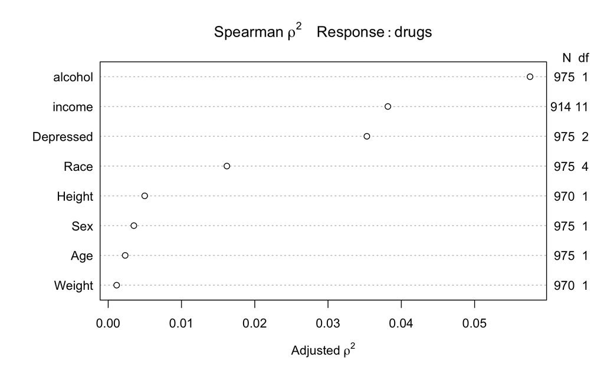

```r
plot(spearman2(drugs ~ Age + Sex + Race + Weight + Height + Depressed + income + alcohol, data = pro1_tidy))
```

# 9 Task 9: Affirmation

This data set meets all requirements specified in the project instructions.

# 10 An Analysis: Linear Regression

We’ll start with a model motivated by the Spearman $\rho^2$ plot developed previously, and repeated below.

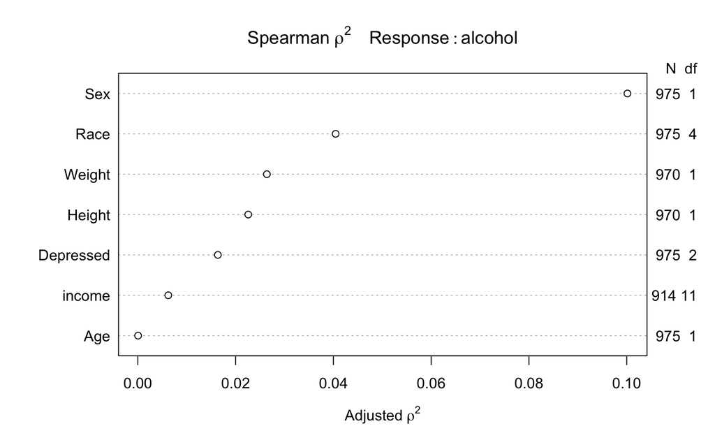

```r
plot(spearman2(alcohol ~ Age + Sex + Race + Weight + Height + Depressed + income, data = pro1_tidy))
```

## 10.1 Model A. Modified Kitchen Sink

```r
d <- datadist(pro1_tidy)
options(datadist = "d")

m.A <- ols(alcohol ~ Sex * Weight + Race + Height +
               Depressed + income + Age ,
           data = pro1_tidy, x = T, y = T)
m.A
```

```
Frequencies of Missing Values Due to Each Variable
  alcohol       Sex    Weight      Race    Height Depressed    income
        0         0         5         0         5         0        61
      Age
        0

Linear Regression Model

 ols(formula = alcohol ~ Sex * Weight + Race + Height + Depressed +
     income + Age, data = pro1_tidy, x = T, y = T)


                Model Likelihood     Discrimination
                   Ratio Test           Indexes
 Obs     911    LR chi2    138.42    R2       0.141
 sigma3.5639    d.f.           22    R2 adj   0.120
 d.f.    888    Pr(> chi2) 0.0000    g        1.591

 Residuals

     Min      1Q  Median      3Q     Max
 -5.9637 -1.5083 -0.4315  0.6982 71.9749


                     Coef    S.E.   t     Pr(>|t|)
 Intercept            2.1314 3.5664  0.60 0.5502
 Sex=female           1.4742 1.1038  1.34 0.1820
 Weight               0.0408 0.0093  4.41 <0.0001
 Race=White           0.4012 0.4254  0.94 0.3459
 Race=Mexican         1.8471 0.5815  3.18 0.0015
 Race=Hispanic        1.2699 0.6068  2.09 0.0366
 Race=Other           1.5505 0.6060  2.56 0.0107
 Height               0.0041 0.0195  0.21 0.8342
 Depressed=Several   -1.0844 0.6302 -1.72 0.0857
 Depressed=None      -2.0886 0.5641 -3.70 0.0002
 income= 5000-9999    1.9380 1.3723  1.41 0.1582
 income=10000-14999  -1.9151 1.2272 -1.56 0.1190
 income=15000-19999  -1.5328 1.2349 -1.24 0.2149
 income=20000-24999   0.1195 1.1598  0.10 0.9180
 income=25000-34999  -0.9482 1.1129 -0.85 0.3944
 income=35000-44999  -0.9876 1.1159 -0.89 0.3764
 income=45000-54999  -1.3036 1.1352 -1.15 0.2511
 income=55000-64999  -1.3448 1.1610 -1.16 0.2470
 income=65000-74999  -0.9179 1.1474 -0.80 0.4239
 income=75000-99999  -1.2056 1.0951 -1.10 0.2713
 income=more 99999   -1.2862 1.0750 -1.20 0.2318
 Age                 -0.0107 0.0187 -0.57 0.5686
 Sex=female * Weight -0.0333 0.0128 -2.60 0.0095
```

### 10.1.1 ANOVA plot

```r
anova(m.A)
```

```
                Analysis of Variance          Response: alcohol

 Factor                                      d.f. Partial SS   MS
 Sex  (Factor+Higher Order Factors)            2  2.552444e+02 127.6221890
  All Interactions                             1  8.576175e+01  85.7617485
 Weight  (Factor+Higher Order Factors)         2  2.503269e+02 125.1634347
  All Interactions                             1  8.576175e+01  85.7617485
 Race                                          4  2.204228e+02  55.1056936
 Height                                        1  5.565692e-01   0.5565692
 Depressed                                     2  2.468134e+02 123.4066977
 income                                       11  2.737437e+02  24.8857941
 Age                                           1  4.131141e+00   4.1311407
 Sex * Weight  (Factor+Higher Order Factors)   1  8.576175e+01  85.7617485
 REGRESSION                                   22  1.850847e+03  84.1294176
 ERROR                                       888  1.127896e+04  12.7015262
 F     P
 10.05 <.0001
  6.75 0.0095
  9.85 0.0001
  6.75 0.0095
  4.34 0.0018
  0.04 0.8342
  9.72 0.0001
  1.96 0.0294
  0.33 0.5686
  6.75 0.0095
  6.62 <.0001
```

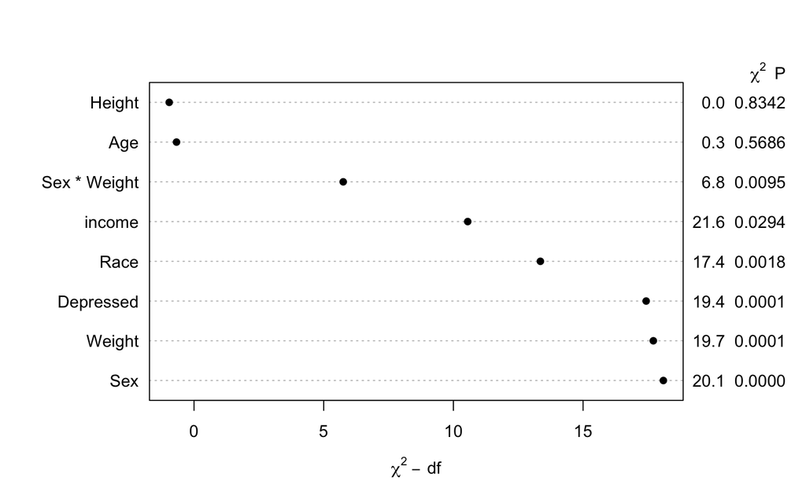

```r
plot(anova(m.A))
```

According to the ANOVA, `Height` and `Age` are not statistically significant pieces of the puzzle. But first, let’s run this Model A again, but this time accounting for the missing values through multiple imputation.

## 10.2 Model A (with imputation)

### 10.2.1 Imputation Model

```r
f.A <- aregImpute(~ Height + Weight + income,
                  data = pro1_tidy,
                  n.impute = 100,
                  pr = FALSE, x = TRUE)
f.A
```

```
Multiple Imputation using Bootstrap and PMM

aregImpute(formula = ~Height + Weight + income, data = pro1_tidy,
    n.impute = 100, x = TRUE, pr = FALSE)

n: 975  p: 3    Imputations: 100    nk: 3

Number of NAs:
Height Weight income
     5      5     61

       type d.f.
Height    s    2
Weight    s    2
income    c   11

Transformation of Target Variables Forced to be Linear

R-squares for Predicting Non-Missing Values for Each Variable
Using Last Imputations of Predictors
Height Weight income
 0.316  0.258  0.079
```

### 10.2.2 Fitting the Model after Imputation

```r
fmi.m.A <- fit.mult.impute(alcohol ~ Sex * Weight + Race + Height +
               Depressed + income + Age ,
                           ols, f.A, data = pro1_tidy)
```

```
Variance Inflation Factors Due to Imputation:

          Intercept          Sex=female              Weight
               1.01                1.00                1.00
         Race=White        Race=Mexican       Race=Hispanic
               1.00                1.00                1.00
         Race=Other              Height   Depressed=Several
               1.00                1.00                1.01
     Depressed=None   income= 5000-9999  income=10000-14999
               1.01                1.04                1.05
 income=15000-19999  income=20000-24999  income=25000-34999
               1.06                1.06                1.06
 income=35000-44999  income=45000-54999  income=55000-64999
               1.05                1.05                1.06
 income=65000-74999  income=75000-99999   income=more 99999
               1.05                1.06                1.06
                Age Sex=female * Weight
               1.00                1.00

Rate of Missing Information:

          Intercept          Sex=female              Weight
               0.01                0.00                0.00
         Race=White        Race=Mexican       Race=Hispanic
               0.00                0.00                0.00
         Race=Other              Height   Depressed=Several
               0.00                0.00                0.01
     Depressed=None   income= 5000-9999  income=10000-14999
               0.01                0.04                0.05
 income=15000-19999  income=20000-24999  income=25000-34999
               0.06                0.05                0.05
 income=35000-44999  income=45000-54999  income=55000-64999
               0.05                0.05                0.06
 income=65000-74999  income=75000-99999   income=more 99999
               0.05                0.05                0.05
                Age Sex=female * Weight
               0.00                0.00

d.f. for t-distribution for Tests of Single Coefficients:

          Intercept          Sex=female              Weight
         2315506.11          5415056.90         19736297.54
         Race=White        Race=Mexican       Race=Hispanic
         8293826.87          5679733.60          8399081.70
         Race=Other              Height   Depressed=Several
         4667859.36          5128417.15          2812670.53
     Depressed=None   income= 5000-9999  income=10000-14999
         1629642.70            58335.41            38899.95
 income=15000-19999  income=20000-24999  income=25000-34999
           32668.44            36273.09            35836.17
 income=35000-44999  income=45000-54999  income=55000-64999
           45354.78            39817.55            29382.92
 income=65000-74999  income=75000-99999   income=more 99999
           39869.13            33324.89            33300.96
                Age Sex=female * Weight
        11268209.73          5742271.42

The following fit components were averaged over the 100 model fits:

  fitted.values stats linear.predictors
```

```r
fmi.m.A
```

```
Linear Regression Model

 fit.mult.impute(formula = alcohol ~ Sex * Weight + Race + Height +
     Depressed + income + Age, fitter = ols, xtrans = f.A, data = pro1_tidy)

                Model Likelihood     Discrimination
                   Ratio Test           Indexes
 Obs     975    LR chi2    142.61    R2       0.136
 sigma3.5272    d.f.           22    R2 adj   0.116
 d.f.    952    Pr(> chi2) 0.0000    g        1.552

 Residuals

     Min      1Q  Median      3Q     Max
 -6.3622 -1.5905 -0.4733  0.7555 72.4131


                     Coef    S.E.   t     Pr(>|t|)
 Intercept            4.1769 3.3867  1.23 0.2178
 Sex=female           1.1205 1.0515  1.07 0.2869
 Weight               0.0388 0.0089  4.35 <0.0001
 Race=White           0.4690 0.4037  1.16 0.2457
 Race=Mexican         1.6264 0.5426  3.00 0.0028
 Race=Hispanic        1.5102 0.5797  2.61 0.0093
 Race=Other           1.5409 0.5677  2.71 0.0068
 Height              -0.0072 0.0185 -0.39 0.6990
 Depressed=Several   -1.3292 0.6063 -2.19 0.0286
 Depressed=None      -2.1879 0.5459 -4.01 <0.0001
 income= 5000-9999    1.8634 1.3366  1.39 0.1636
 income=10000-14999  -1.8261 1.1933 -1.53 0.1263
 income=15000-19999  -1.4733 1.2071 -1.22 0.2226
 income=20000-24999   0.1427 1.1256  0.13 0.8991
 income=25000-34999  -0.8725 1.0811 -0.81 0.4199
 income=35000-44999  -0.9448 1.0811 -0.87 0.3824
 income=45000-54999  -1.2602 1.1013 -1.14 0.2528
 income=55000-64999  -1.3246 1.1325 -1.17 0.2424
 income=65000-74999  -0.8629 1.1141 -0.77 0.4388
 income=75000-99999  -1.1404 1.0638 -1.07 0.2840
 income=more 99999   -1.2137 1.0439 -1.16 0.2453
 Age                 -0.0052 0.0178 -0.29 0.7688
 Sex=female * Weight -0.0310 0.0122 -2.54 0.0114
```

### 10.2.3 ANOVA plot after imputation

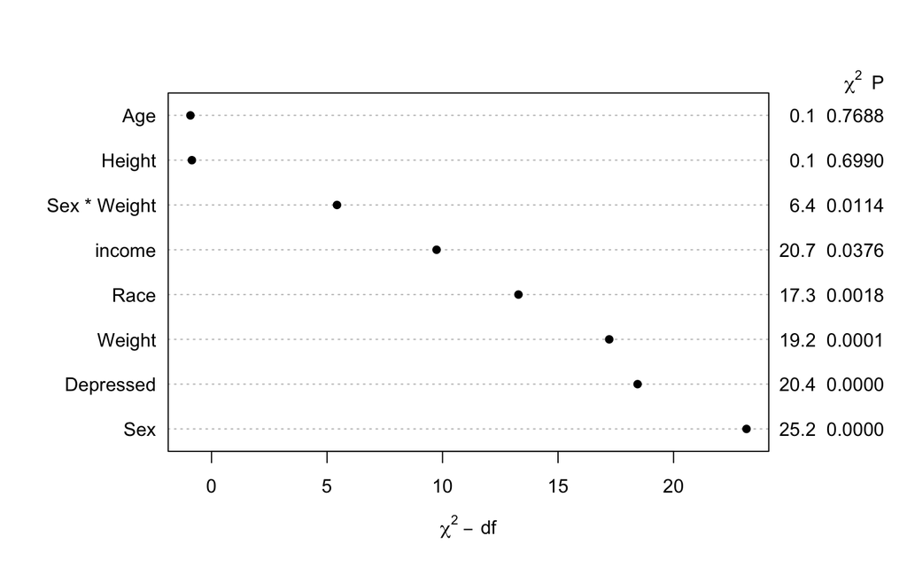

```r
plot(anova(fmi.m.A))
```

### 10.2.4 Effects plot after imputation

```r
summary(fmi.m.A)
```

```
             Effects              Response : alcohol

 Factor                          Low   High    Diff.  Effect    S.E.
 Weight                           68.9  94.475 25.575  0.991910 0.22825
 Height                          164.4 178.300 13.900 -0.099611 0.25755
 Age                              30.0  41.000 11.000 -0.057547 0.19569
 Sex - female:male                 1.0   2.000     NA -1.409700 0.32677
 Race - Black:White                2.0   1.000     NA -0.469010 0.40373
 Race - Mexican:White              2.0   3.000     NA  1.157400 0.42641
 Race - Hispanic:White             2.0   4.000     NA  1.041200 0.47049
 Race - Other:White                2.0   5.000     NA  1.071900 0.44177
 Depressed - Most:None             3.0   1.000     NA  2.187900 0.54591
 Depressed - Several:None          3.0   2.000     NA  0.858690 0.33629
 income -  0-4999:more 99999      12.0   1.000     NA  1.213700 1.04390
 income -  5000-9999:more 99999   12.0   2.000     NA  3.077100 0.92179
 income - 10000-14999:more 99999  12.0   3.000     NA -0.612450 0.65576
 income - 15000-19999:more 99999  12.0   4.000     NA -0.259690 0.69718
 income - 20000-24999:more 99999  12.0   5.000     NA  1.356400 0.54500
 income - 25000-34999:more 99999  12.0   6.000     NA  0.341180 0.43800
 income - 35000-44999:more 99999  12.0   7.000     NA  0.268860 0.44636
 income - 45000-54999:more 99999  12.0   8.000     NA -0.046505 0.47410
 income - 55000-64999:more 99999  12.0   9.000     NA -0.110920 0.53266
 income - 65000-74999:more 99999  12.0  10.000     NA  0.350780 0.50566
 income - 75000-99999:more 99999  12.0  11.000     NA  0.073244 0.36986
 Lower 0.95 Upper 0.95
  0.54397    1.43980
 -0.60504    0.40582
 -0.44158    0.32649
 -2.05100   -0.76842
 -1.26130    0.32329
  0.32062    1.99430
  0.11790    1.96450
  0.20489    1.93880
  1.11650    3.25920
  0.19873    1.51860
 -0.83492    3.26220
  1.26810    4.88600
 -1.89940    0.67444
 -1.62790    1.10850
  0.28683    2.42590
 -0.51837    1.20070
 -0.60711    1.14480
 -0.97690    0.88389
 -1.15620    0.93441
 -0.64157    1.34310
 -0.65260    0.79909

Adjusted to: Sex=male Weight=81.6
```

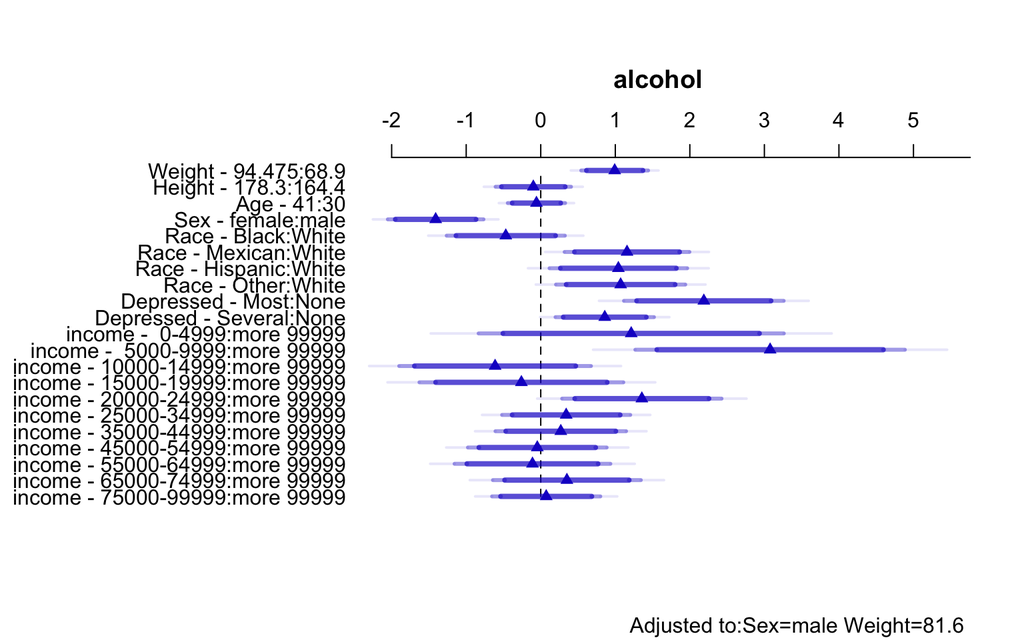

```r
plot(summary(fmi.m.A))
```

### 10.2.5 Nomogram after imputation

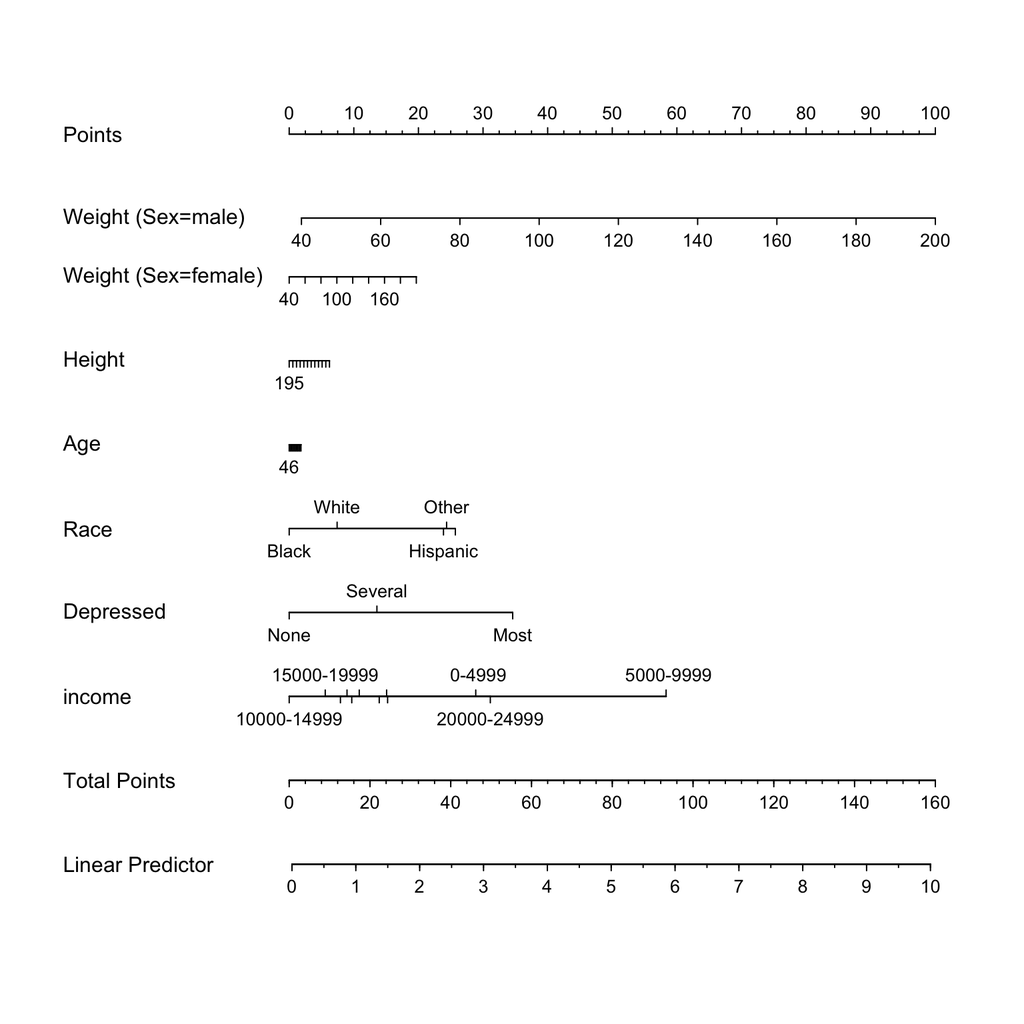

```r
plot(nomogram(fmi.m.A))
```

## 10.3 Running “Best Subsets” to select predictors

Mostly for completeness, next we’ll consider models with main effects only, again just excluding the observations with missing values, and run our “best subsets” comparisons to consider potential models.

```r
preds <- with(na.omit(pro1_tidy), cbind(Sex, Weight, Race, Height,
               Depressed, income, Age))
x1 <- regsubsets(preds, na.omit(pro1_tidy)$alcohol, nvmax=7)
rs <- summary(x1)
rs
```

```
Subset selection object
7 Variables  (and intercept)
          Forced in Forced out
Sex           FALSE      FALSE
Weight        FALSE      FALSE
Race          FALSE      FALSE
Height        FALSE      FALSE
Depressed     FALSE      FALSE
income        FALSE      FALSE
Age           FALSE      FALSE
1 subsets of each size up to 7
Selection Algorithm: exhaustive
         Sex Weight Race Height Depressed income Age
1  ( 1 ) "*" " "    " "  " "    " "       " "    " "
2  ( 1 ) "*" " "    " "  " "    "*"       " "    " "
3  ( 1 ) "*" "*"    " "  " "    "*"       " "    " "
4  ( 1 ) "*" "*"    "*"  " "    "*"       " "    " "
5  ( 1 ) "*" "*"    "*"  " "    "*"       "*"    " "
6  ( 1 ) "*" "*"    "*"  " "    "*"       "*"    "*"
7  ( 1 ) "*" "*"    "*"  "*"    "*"       "*"    "*"
```

```r
round(rs$adjr2, 4)
```

```
[1] 0.0548 0.0742 0.0866 0.1030 0.1068 0.1062 0.1053
```

```r
round(rs$cp, 1)
```

```
[1] 53.3 34.5 22.9  7.3  4.4  6.0  8.0
```

```r
round(rs$bic, 1)
```

```
[1] -38.7 -51.8 -58.3 -68.9 -67.0 -60.6 -53.8
```

```r
rs$aic.corr <- 292*log(rs$rss / 292) + 2*(2:8) +
               (2 * (2:8) * ((2:8)+1) / (292 - (2:8) - 1))
round(rs$aic.corr,1)
```

```
[1] 1098.6 1094.3 1092.0 1088.5 1089.0 1091.0 1093.1
```

### 10.3.1 Building the Four Summary Plots

```r
best_mods_1 <- data_frame( k = 2:8,
                           r2 = rs$rsq, adjr2 = rs$adjr2, cp = rs$cp, aic.c = rs$aic.c, bic = rs$bic)
rs <- cbind(best_mods_1, rs$which)
```

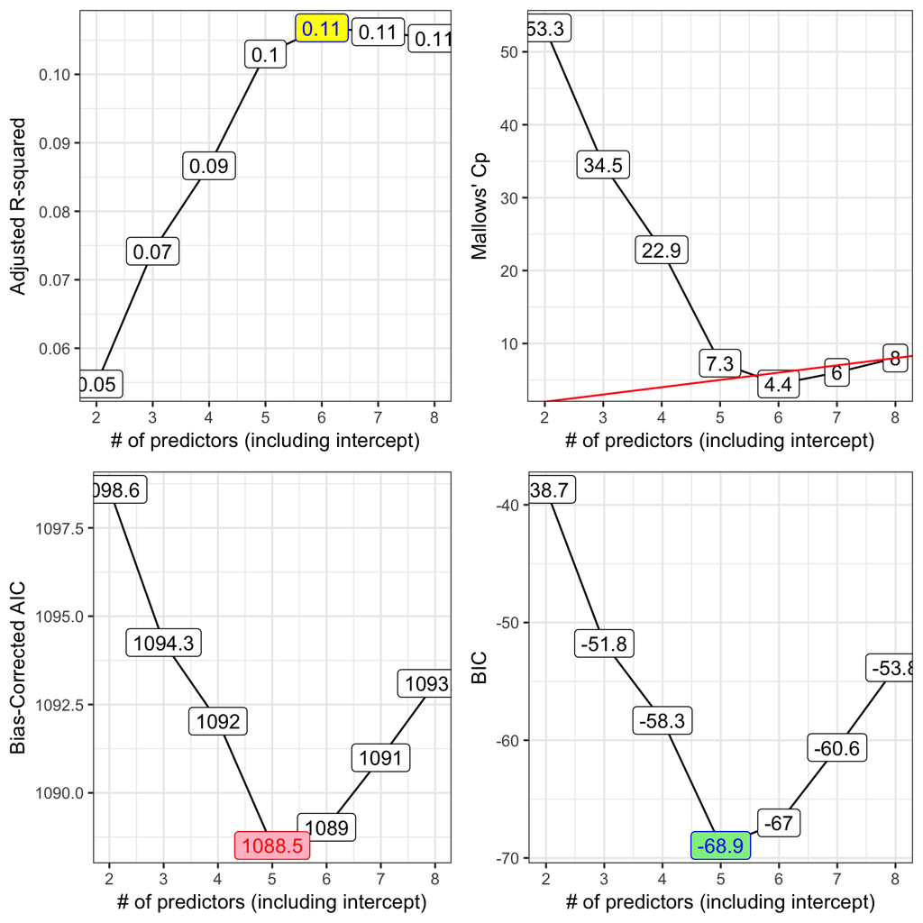

```r
p1<- ggplot(rs, aes(x = k, y = adjr2,label = round(adjr2,2))) +
  geom_line() +
  geom_label() +
  geom_label(data = subset(rs,adjr2 == max(adjr2)),aes(x = k, y = adjr2, label = round(adjr2,2)),
             fill = "yellow", col = "blue") + theme_bw() +
  scale_x_continuous(breaks = 2:8) +
  labs(x = "# of predictors (including intercept)",y = "Adjusted R-squared")

p2<- ggplot(rs, aes(x = k, y = cp,
                   label = round(cp,1))) +
  geom_line() +geom_label() +geom_abline(intercept = 0, slope = 1,col = "red") + theme_bw() +
  scale_x_continuous(breaks = 2:8) +
  labs(x = "# of predictors (including intercept)",y = "Mallows' Cp")

p3<- ggplot(rs, aes(x = k, y = aic.c,label = round(aic.c,1))) +geom_line() +
  geom_label() +geom_label(data = subset(rs, aic.c == min(aic.c)),aes(x = k, y = aic.c), fill = "pink",
                           col = "red") + theme_bw() +
  scale_x_continuous(breaks = 2:8) +labs(x = "# of predictors (including intercept)",y = "Bias-Corrected AIC")

p4<- ggplot(rs, aes(x = k, y = bic,label = round(bic,1))) +
  geom_line() +
  geom_label() +
  geom_label(data = subset(rs, bic == min(bic)),aes(x = k, y = bic),fill = "lightgreen", col = "blue") + theme_bw() +
  scale_x_continuous(breaks = 2:8) +
  labs(x = "# of predictors (including intercept)",y = "BIC")
gridExtra::grid.arrange(p1, p2, p3, p4, nrow = 2)
```

### 10.3.2 Candidate Models from “Best Subsets”

[output not shown]

### 10.3.3 Comparison of Candidate Models via ANOVA

```r
lm0 <- lm(alcohol ~ 1, data = na.omit(pro1_tidy))
lm5 <- lm(alcohol ~ Sex + Race + Weight + Depressed, data = na.omit(pro1_tidy))
lm6 <- lm(alcohol ~ Sex + Race + Weight + Depressed + Age,
           data = na.omit(pro1_tidy))
```

```r
anova(lm6, lm5, lm0)
```

```
Analysis of Variance Table

Model 1: alcohol ~ Sex + Race + Weight + Depressed + Age
Model 2: alcohol ~ Sex + Race + Weight + Depressed
Model 3: alcohol ~ 1
  Res.Df   RSS Df Sum of Sq       F Pr(>F)
1    901 11626
2    902 11633 -1     -7.53  0.5839  0.445
3    910 13130 -8  -1496.57 14.4981 <2e-16 ***
---
Signif. codes:  0 '***' 0.001 '**' 0.01 '*' 0.05 '.' 0.1 ' ' 1
```

## 10.4 Model B

```r
m.B <- ols(alcohol ~ Sex + Race + Weight + Depressed,
           data = pro1_tidy, x = T, y = T)
m.B
```

```
Frequencies of Missing Values Due to Each Variable
  alcohol       Sex      Race    Weight Depressed
        0         0         0         5         0

Linear Regression Model

 ols(formula = alcohol ~ Sex + Race + Weight + Depressed, data = pro1_tidy,
     x = T, y = T)


                Model Likelihood     Discrimination
                   Ratio Test           Indexes
 Obs     970    LR chi2    113.53    R2       0.110
 sigma3.5607    d.f.            8    R2 adj   0.103
 d.f.    961    Pr(> chi2) 0.0000    g        1.426

 Residuals

     Min      1Q  Median      3Q     Max
 -5.6089 -1.6589 -0.4496  0.7124 74.5748


                   Coef    S.E.   t     Pr(>|t|)
 Intercept          2.9984 0.8617  3.48 0.0005
 Sex=female        -1.3524 0.2473 -5.47 <0.0001
 Race=White         0.3530 0.3949  0.89 0.3716
 Race=Mexican       1.7491 0.5269  3.32 0.0009
 Race=Hispanic      1.4559 0.5652  2.58 0.0102
 Race=Other         1.7056 0.5631  3.03 0.0025
 Weight             0.0243 0.0061  3.97 <0.0001
 Depressed=Several -1.3581 0.5949 -2.28 0.0227
 Depressed=None    -2.0985 0.5208 -4.03 <0.0001
```

### 10.4.1 ANOVA plot for Model B

The ANOVA plot after an `ols` fit just re-iterates the information from the *t* tests.

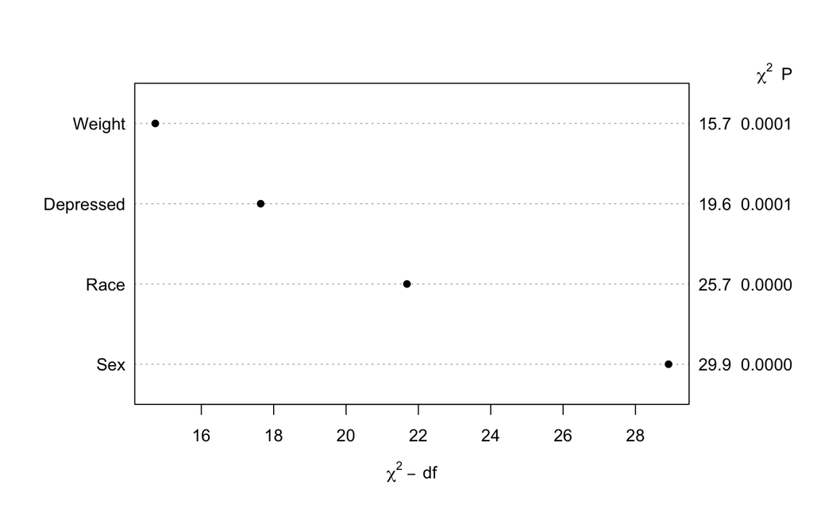

```r
plot(anova(m.B))
```

### 10.4.2 Validation of Model B Summary Statistics

```r
set.seed(432); validate(m.B)
```

```
          index.orig training    test optimism index.corrected  n
R-square      0.1105   0.1361  0.0922   0.0440          0.0665 40
MSE          12.5609  10.4234 12.8193  -2.3959         14.9568 40
g             1.4255   1.3819  1.3041   0.0778          1.3477 40
Intercept     0.0000   0.0000  0.1659  -0.1659          0.1659 40
Slope         1.0000   1.0000  0.9639   0.0361          0.9639 40
```

### 10.4.3 Nomogram of Model B

The nomogram is very simple, since each predictor only enters the model linearly.

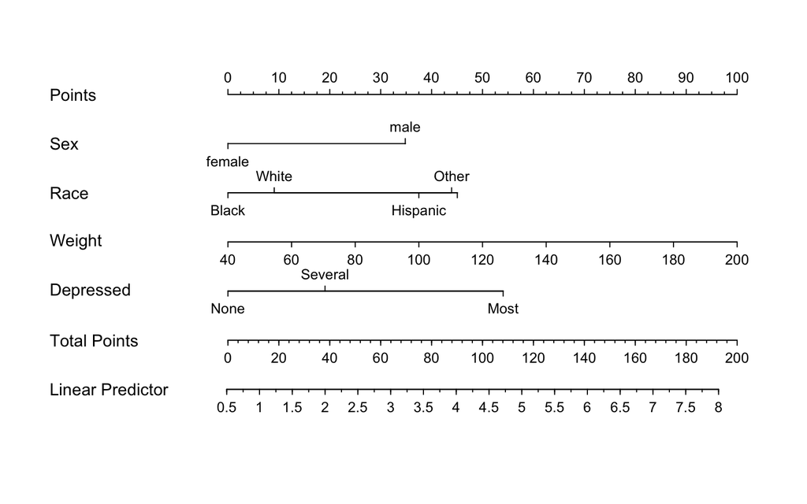

```r
plot(nomogram(m.B))
```

### 10.4.4 Fitting Model B with `lm`

We can fit Model B using `lm` and then plot residuals, if we like.

```r
model.B <- lm(alcohol ~ Sex + Race + Weight + Depressed,
              data = pro1_tidy)
display(model.B)
```

```
lm(formula = alcohol ~ Sex + Race + Weight + Depressed, data = pro1_tidy)
                 coef.est coef.se
(Intercept)       3.00     0.86
Sexfemale        -1.35     0.25
RaceWhite         0.35     0.39
RaceMexican       1.75     0.53
RaceHispanic      1.46     0.57
RaceOther         1.71     0.56
Weight            0.02     0.01
DepressedSeveral -1.36     0.59
DepressedNone    -2.10     0.52
---
n = 970, k = 9
residual sd = 3.56, R-Squared = 0.11
```

### 10.4.5 Residual Plots for Model B

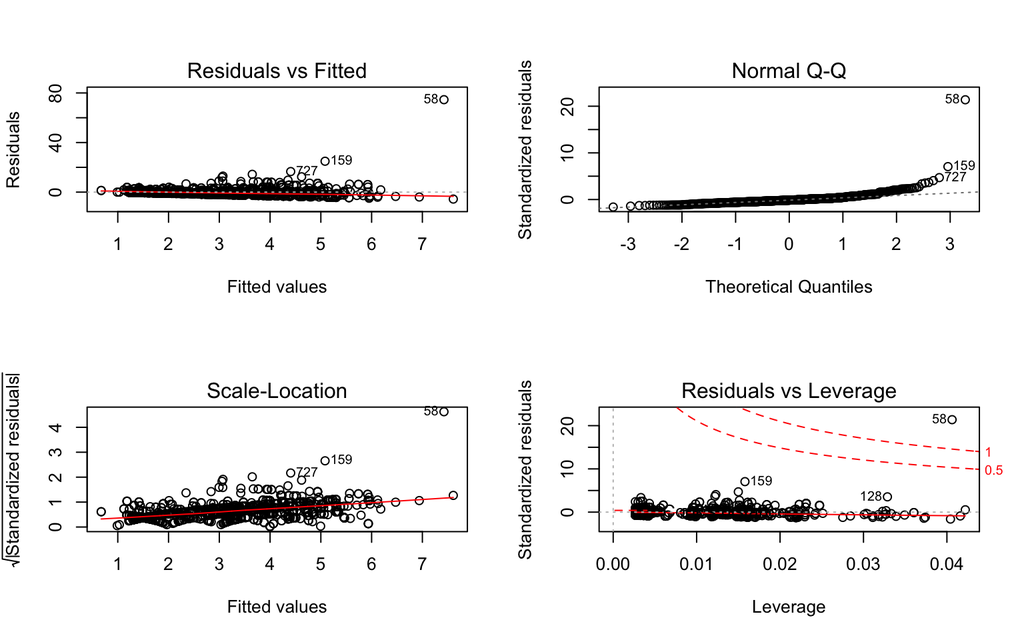

```r
par(mfrow=c(2,2))
plot(model.B)
```

```r
par(mfrow=c(1,1))
```

JIAJIAN HUANG

2018-03-08 10:21:16